# CS 422 Section 01

Avinash Vellineni

## Homework 2

## Problem 2

### Question 2.1 - A

```r
rm(list = ls())
setwd("E:/IIT CHICAGO STUDIES/IIT Chicago semester 2/Data Mining/Assignments/Assignment2")
set.seed(1122)
```

Data Cleaning

```r
train <- read.csv("adult-train.csv", header=T, sep=",")
head(train)
```

|  | age | workclass | fnlwgt | education | education_num | marital_status | occupation | relationship | race | sex | capital_gain | capital_loss | hours_per_week | native_country | income |
| --- | --- | --- | --- | --- | --- | --- | --- | --- | --- | --- | --- | --- | --- | --- | --- |
| 1 | 39 | State-gov | 77516 | Bachelors | 13 | Never-married | Adm-clerical | Not-in-family | White | Male | 2174 | 0 | 40 | United-States | <=50K |
| 2 | 50 | Self-emp-not-inc | 83311 | Bachelors | 13 | Married-civ-spouse | Exec-managerial | Husband | White | Male | 0 | 0 | 13 | United-States | <=50K |
| 3 | 38 | Private | 215646 | HS-grad | 9 | Divorced | Handlers-cleaners | Not-in-family | White | Male | 0 | 0 | 40 | United-States | <=50K |
| 4 | 53 | Private | 234721 | 11th | 7 | Married-civ-spouse | Handlers-cleaners | Husband | Black | Male | 0 | 0 | 40 | United-States | <=50K |
| 5 | 28 | Private | 338409 | Bachelors | 13 | Married-civ-spouse | Prof-specialty | Wife | Black | Female | 0 | 0 | 40 | Cuba | <=50K |
| 6 | 37 | Private | 284582 | Masters | 14 | Married-civ-spouse | Exec-managerial | Wife | White | Female | 0 | 0 | 40 | United-States | <=50K |

```r
test <-  read.csv("adult-test.csv", header = T, sep=",")
head(test)
```

|  | age | workclass | fnlwgt | education | education_num | marital_status | occupation | relationship | race | sex | capital_gain | capital_loss | hours_per_week | native_country | income |
| --- | --- | --- | --- | --- | --- | --- | --- | --- | --- | --- | --- | --- | --- | --- | --- |
| 1 | 25 | Private | 226802 | 11th | 7 | Never-married | Machine-op-inspct | Own-child | Black | Male | 0 | 0 | 40 | United-States | <=50K |
| 2 | 38 | Private | 89814 | HS-grad | 9 | Married-civ-spouse | Farming-fishing | Husband | White | Male | 0 | 0 | 50 | United-States | <=50K |
| 3 | 28 | Local-gov | 336951 | Assoc-acdm | 12 | Married-civ-spouse | Protective-serv | Husband | White | Male | 0 | 0 | 40 | United-States | >50K |
| 4 | 44 | Private | 160323 | Some-college | 10 | Married-civ-spouse | Machine-op-inspct | Husband | Black | Male | 7688 | 0 | 40 | United-States | >50K |
| 5 | 18 | ? | 103497 | Some-college | 10 | Never-married | ? | Own-child | White | Female | 0 | 0 | 30 | United-States | <=50K |
| 6 | 34 | Private | 198693 | 10th | 6 | Never-married | Other-service | Not-in-family | White | Male | 0 | 0 | 30 | United-States | <=50K |

removing ? in the training dataset

```r
sum(train$workclass == "?")
```

```
[1] 1836
```

```r
list1 <- which(train$workclass == "?")
sum(train$occupation == "?")
```

```
[1] 1843
```

```r
list2 <- which(train$occupation == "?")
sum(train$native_country == "?")
```

```
[1] 583
```

```r
list3 <- which(train$native_country == "?")
train_index <- c(list1,list2,list3)
train <- train[-train_index,]
train
```

|  | age | workclass | fnlwgt | education | education_num | marital_status | occupation | relationship | race | sex | capital_gain | capital_loss | hours_per_week | native_country | income |
| --- | --- | --- | --- | --- | --- | --- | --- | --- | --- | --- | --- | --- | --- | --- | --- |
| 1 | 39 | State-gov | 77516 | Bachelors | 13 | Never-married | Adm-clerical | Not-in-family | White | Male | 2174 | 0 | 40 | United-States | <=50K |
| 2 | 50 | Self-emp-not-inc | 83311 | Bachelors | 13 | Married-civ-spouse | Exec-managerial | Husband | White | Male | 0 | 0 | 13 | United-States | <=50K |
| 3 | 38 | Private | 215646 | HS-grad | 9 | Divorced | Handlers-cleaners | Not-in-family | White | Male | 0 | 0 | 40 | United-States | <=50K |
| 4 | 53 | Private | 234721 | 11th | 7 | Married-civ-spouse | Handlers-cleaners | Husband | Black | Male | 0 | 0 | 40 | United-States | <=50K |
| 5 | 28 | Private | 338409 | Bachelors | 13 | Married-civ-spouse | Prof-specialty | Wife | Black | Female | 0 | 0 | 40 | Cuba | <=50K |
| 6 | 37 | Private | 284582 | Masters | 14 | Married-civ-spouse | Exec-managerial | Wife | White | Female | 0 | 0 | 40 | United-States | <=50K |
| 7 | 49 | Private | 160187 | 9th | 5 | Married-spouse-absent | Other-service | Not-in-family | Black | Female | 0 | 0 | 16 | Jamaica | <=50K |
| 8 | 52 | Self-emp-not-inc | 209642 | HS-grad | 9 | Married-civ-spouse | Exec-managerial | Husband | White | Male | 0 | 0 | 45 | United-States | >50K |
| 9 | 31 | Private | 45781 | Masters | 14 | Never-married | Prof-specialty | Not-in-family | White | Female | 14084 | 0 | 50 | United-States | >50K |
| 10 | 42 | Private | 159449 | Bachelors | 13 | Married-civ-spouse | Exec-managerial | Husband | White | Male | 5178 | 0 | 40 | United-States | >50K |

[output cut: 990 more lines]

removing ? in the test dataset

```r
sum(test$workclass == "?")
```

```
[1] 963
```

```r
list4 <- which(test$workclass == "?")
sum(test$occupation == "?")
```

```
[1] 966
```

```r
list5 <- which(test$occupation == "?")
sum(test$native_country == "?")
```

```
[1] 274
```

```r
list6 <- which(test$native_country == "?")
test_index <- c(list4,list5,list6)
test <- test[-test_index,]
test
```

|  | age | workclass | fnlwgt | education | education_num | marital_status | occupation | relationship | race | sex | capital_gain | capital_loss | hours_per_week | native_country | income |
| --- | --- | --- | --- | --- | --- | --- | --- | --- | --- | --- | --- | --- | --- | --- | --- |
| 1 | 25 | Private | 226802 | 11th | 7 | Never-married | Machine-op-inspct | Own-child | Black | Male | 0 | 0 | 40 | United-States | <=50K |
| 2 | 38 | Private | 89814 | HS-grad | 9 | Married-civ-spouse | Farming-fishing | Husband | White | Male | 0 | 0 | 50 | United-States | <=50K |
| 3 | 28 | Local-gov | 336951 | Assoc-acdm | 12 | Married-civ-spouse | Protective-serv | Husband | White | Male | 0 | 0 | 40 | United-States | >50K |
| 4 | 44 | Private | 160323 | Some-college | 10 | Married-civ-spouse | Machine-op-inspct | Husband | Black | Male | 7688 | 0 | 40 | United-States | >50K |
| 6 | 34 | Private | 198693 | 10th | 6 | Never-married | Other-service | Not-in-family | White | Male | 0 | 0 | 30 | United-States | <=50K |
| 8 | 63 | Self-emp-not-inc | 104626 | Prof-school | 15 | Married-civ-spouse | Prof-specialty | Husband | White | Male | 3103 | 0 | 32 | United-States | >50K |
| 9 | 24 | Private | 369667 | Some-college | 10 | Never-married | Other-service | Unmarried | White | Female | 0 | 0 | 40 | United-States | <=50K |
| 10 | 55 | Private | 104996 | 7th-8th | 4 | Married-civ-spouse | Craft-repair | Husband | White | Male | 0 | 0 | 10 | United-States | <=50K |
| 11 | 65 | Private | 184454 | HS-grad | 9 | Married-civ-spouse | Machine-op-inspct | Husband | White | Male | 6418 | 0 | 40 | United-States | >50K |
| 12 | 36 | Federal-gov | 212465 | Bachelors | 13 | Married-civ-spouse | Adm-clerical | Husband | White | Male | 0 | 0 | 40 | United-States | <=50K |

[output cut: 990 more lines]

End of data cleaning

### Question 2.1 - B - (i)

```r
library(rpart)
library(caret)
library(rpart.plot)
library(ROCR)
```

Building model using the training dataset

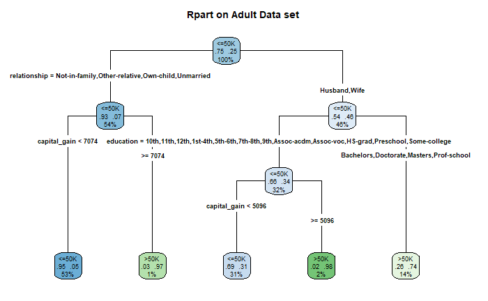

```r
model_train <- rpart(income ~ ., method="class", data=train)
rpart.plot(model_train, extra=104, fallen.leaves = T, type=4, main="Rpart on Adult Data set")
```

```r
summary(model_train)
```

```
Call:
rpart(formula = income ~ ., data = train, method = "class")
  n= 30161

          CP nsplit rel error    xerror        xstd
1 0.12999467      0 1.0000000 1.0000000 0.010001793
2 0.06419819      2 0.7400107 0.7400107 0.008966969
3 0.03729355      3 0.6758125 0.6758125 0.008652716
4 0.01000000      4 0.6385189 0.6385189 0.008457392

Variable importance
  relationship marital_status   capital_gain      education  education_num            sex
            24             23             10              9              9              8
    occupation            age hours_per_week
             7              5              3

Node number 1: 30161 observations,    complexity param=0.1299947
  predicted class=<=50K  expected loss=0.2489307  P(node) =1
    class counts: 22653  7508
   probabilities: 0.751 0.249
  left son=2 (16292 obs) right son=3 (13869 obs)
  Primary splits:
      relationship   splits as  RLLLLR, improve=2277.164, (0 missing)
      marital_status splits as  LRRLLLL, improve=2244.398, (0 missing)
      capital_gain   < 5119   to the left,  improve=1540.825, (0 missing)
      education      splits as  LLLLLLLLLRRLRLRL, improve=1193.769, (0 missing)
      education_num  < 12.5   to the left,  improve=1193.769, (0 missing)
  Surrogate splits:
      marital_status splits as  LRRLLLL, agree=0.993, adj=0.984, (0 split)
      sex            splits as  LR, agree=0.691, adj=0.328, (0 split)
      age            < 33.5   to the left,  agree=0.645, adj=0.229, (0 split)
      occupation     splits as  -LLRRRLLLLRRLLR, agree=0.620, adj=0.175, (0 split)
      hours_per_week < 43.5   to the left,  agree=0.604, adj=0.138, (0 split)

Node number 2: 16292 observations,    complexity param=0.03729355
  predicted class=<=50K  expected loss=0.06966609  P(node) =0.5401678
    class counts: 15157  1135
   probabilities: 0.930 0.070
  left son=4 (15992 obs) right son=5 (300 obs)
  Primary splits:
```

[output cut: 45 more lines]

```

Node number 7: 4150 observations
  predicted class=>50K   expected loss=0.2648193  P(node) =0.1375949
    class counts:  1099  3051
   probabilities: 0.265 0.735

Node number 12: 9219 observations
  predicted class=<=50K  expected loss=0.3070832  P(node) =0.3056596
    class counts:  6388  2831
   probabilities: 0.693 0.307

Node number 13: 500 observations
  predicted class=>50K   expected loss=0.018  P(node) =0.0165777
    class counts:     9   491
   probabilities: 0.018 0.982
```

The top three important predictors in the model are relationship,marital_status,capital_gain

### Question 2.1-B-(ii)

The first split is done on the predictor “Relationship”. The class label is <=50K.

### Question 2.1-C-(i)

Prediction using the test dataset

```r
predict_test <- predict(model_train, test, type="class")
head(predict_test)
```

```
    1     2     3     4     6     8
<=50K <=50K <=50K  >50K <=50K  >50K
Levels: <=50K >50K
```

```r
head(test$income)
```

```
[1] <=50K <=50K >50K  >50K  <=50K >50K
Levels: <=50K >50K
```

```r
cm <- confusionMatrix(predict_test, test[, 15])
cm
```

```
Confusion Matrix and Statistics

          Reference
Prediction <=50K  >50K
     <=50K 10772  1837
     >50K    588  1863

               Accuracy : 0.839
                 95% CI : (0.833, 0.8448)
    No Information Rate : 0.7543
    P-Value [Acc > NIR] : < 2.2e-16

                  Kappa : 0.5098
 Mcnemar's Test P-Value : < 2.2e-16

            Sensitivity : 0.9482
            Specificity : 0.5035
         Pos Pred Value : 0.8543
         Neg Pred Value : 0.7601
             Prevalence : 0.7543
         Detection Rate : 0.7153
   Detection Prevalence : 0.8373
      Balanced Accuracy : 0.7259

       'Positive' Class : <=50K
```

```r
sensitivity_test <- as.numeric(formatC(cm$byClass[1], digits = 3, format = "f"))
specificity_test <- as.numeric(formatC(cm$byClass[2], digits = 3, format = "f"))
balanced_accuracy <-(sensitivity_test+specificity_test)/2
balanced_accuracy <- round(balanced_accuracy,digits = 3)
cat(paste("The Balance Accuracy of the model is ",balanced_accuracy,"\n"))
```

```
The Balance Accuracy of the model is  0.726
```

### Question 2.1-C-(ii)

```r
balance_error_rate <- 1.0 - balanced_accuracy
cat(paste("The Balance error rate of the model is ",balance_error_rate,"\n"))
```

```
The Balance error rate of the model is  0.274
```

### Question 2.1-C-(iii)

```r
cat(paste("The Sensitivity of the model is ",sensitivity_test,"\n"))
```

```
The Sensitivity of the model is  0.948
```

```r
cat(paste("The Specificity of the model is ",specificity_test,"\n"))
```

```
The Specificity of the model is  0.504
```

### Question 2.1-C-(iV)

Roc Curve

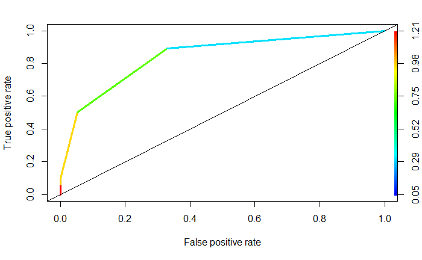

```r
pred.rocr <- predict(model_train, newdata=test, type="prob")[,2]
f.pred <- prediction(pred.rocr, test$income)
f.perf <- performance(f.pred, "tpr", "fpr")
plot(f.perf, colorize=T, lwd=3)
abline(0,1)
```

```r
auc <- performance(f.pred, measure = "auc")
cat(paste("The area under curve (AUC) for this model is ", round(auc@y.values[[1]], 3)))
```

```
The area under curve (AUC) for this model is  0.843
```

### Question 2.1-D

```r
options("digits"=5)
printcp(model_train)
```

```
Classification tree:
rpart(formula = income ~ ., data = train, method = "class")

Variables actually used in tree construction:
[1] capital_gain education    relationship

Root node error: 7508/30161 = 0.249

n= 30161

      CP nsplit rel error xerror    xstd
1 0.1300      0     1.000  1.000 0.01000
2 0.0642      2     0.740  0.740 0.00897
3 0.0373      3     0.676  0.676 0.00865
4 0.0100      4     0.639  0.639 0.00846
```

```r
options("digits"=3)
```

The tree would’t benefit from pruning.

Inference from the tree – Variables used in the tree construction are capital_gain,education,relationship.

Error at the root node is 0.249. About 24.9% of the error occured at the root node.

From the summary of the complexity table we can infer that n=30161, the column xerror(cross Validation error) has the lowest value at the 4th split with a complexity of 0.01.

Hence on pruning the tree we will increase the cross validation error.So we dont want to prune the tree since the error is the lowest at the 4th split.

Extracting the Cp value corresponding to the lowest xerror.

```r
cpx=model_train$cptable[which.min(model_train$cptable[,"xerror"]), "CP"]
cpx
```

```
[1] 0.01
```

### Question 2.1-E-(i)

Class imbalance problem

Number of observations in class <=50K and >50K

```r
sum(train$income == "<=50K")
```

```
[1] 22653
```

```r
sum(train$income == ">50K")
```

```
[1] 7508
```

## Question 2.1-E-(ii)

```r
list7 <- sample(which(train$income == "<=50K") , size=sum(train$income == ">50K"))
head(list7)
```

```
[1]  9635 25967 20408 14098 13312 21263
```

```r
list8 <- which(train$income == ">50K")
head(list8)
```

```
[1]  8  9 10 11 12 19
```

```r
new_index <- c(list7,list8)
```

Training model updated with equal number of observations of the two classes.

```r
New_training_model <- train[new_index, ]
sum(New_training_model$income == "<=50K")
```

```
[1] 7508
```

```r
sum(New_training_model$income == ">50K")
```

```
[1] 7508
```

## Question 2.1-E-(iii)

[figure not shown]

```r
New_model <- rpart(income ~ ., method="class", data=New_training_model)
rpart.plot(New_model, extra=104, fallen.leaves = T, type=4, main=" New Rpart on Adult Dataset with equal proportion of test values")
```

```r
summary(New_model)
```

```
Call:
rpart(formula = income ~ ., data = New_training_model, method = "class")
  n= 15016

      CP nsplit rel error xerror    xstd
1 0.5125      0     1.000  1.020 0.00816
2 0.0393      1     0.487  0.487 0.00701
3 0.0116      2     0.448  0.448 0.00681
4 0.0115      6     0.396  0.407 0.00657
5 0.0100      7     0.385  0.394 0.00649

Variable importance
  relationship marital_status     occupation            sex            age   capital_gain
            28             28             10             10              8              7
hours_per_week      education  education_num
             3              2              2

Node number 1: 15016 observations,    complexity param=0.513
  predicted class=<=50K  expected loss=0.5  P(node) =1
    class counts:  7508  7508
   probabilities: 0.500 0.500
  left son=2 (6118 obs) right son=3 (8898 obs)
  Primary splits:
      relationship   splits as  RLLLLR, improve=2040, (0 missing)
      marital_status splits as  LRRLLLL, improve=2030, (0 missing)
      age            < 29.5  to the left,  improve=1010, (0 missing)
      education      splits as  LLLLLLLLLRRLRLRL, improve= 875, (0 missing)
      education_num  < 12.5  to the left,  improve= 875, (0 missing)
  Surrogate splits:
      marital_status splits as  LRRLLLL, agree=0.994, adj=0.984, (0 split)
      sex            splits as  LR, agree=0.732, adj=0.343, (0 split)
      age            < 29.5  to the left,  agree=0.703, adj=0.271, (0 split)
      occupation     splits as  -LLRRRLRLLRRRRR, agree=0.665, adj=0.178, (0 split)
      hours_per_week < 39.5  to the left,  agree=0.643, adj=0.123, (0 split)

Node number 2: 6118 observations,    complexity param=0.0393
  predicted class=<=50K  expected loss=0.186  P(node) =0.407
    class counts:  4983  1135
   probabilities: 0.814 0.186
  left son=4 (5765 obs) right son=5 (353 obs)
```

[output cut: 112 more lines]

```
      relationship   splits as  R----L, agree=0.782, adj=0.050, (0 split)
      sex            splits as  LR, agree=0.782, adj=0.050, (0 split)
      age            < 66.5  to the right, agree=0.777, adj=0.028, (0 split)
      hours_per_week < 31    to the left,  agree=0.776, adj=0.026, (0 split)
      native_country splits as  -RRRRR--RR-RRRL--R-RRRRL-LR-RRRRL-L-RRRRL, agree=0.774, adj=0.015, (0 split)

Node number 102: 464 observations
  predicted class=<=50K  expected loss=0.407  P(node) =0.0309
    class counts:   275   189
   probabilities: 0.593 0.407

Node number 103: 1558 observations
  predicted class=>50K   expected loss=0.381  P(node) =0.104
    class counts:   594   964
   probabilities: 0.381 0.619
```

```r
predinct_New_model <- predict(New_model, test, type="class")
head(predinct_New_model)
```

```
    1     2     3     4     6     8
<=50K <=50K  >50K  >50K <=50K  >50K
Levels: <=50K >50K
```

```r
head(test$income)
```

```
[1] <=50K <=50K >50K  >50K  <=50K >50K
Levels: <=50K >50K
```

```r
new_cm <- confusionMatrix(predinct_New_model, test[,15])
new_cm$byClass
```

```
         Sensitivity          Specificity       Pos Pred Value       Neg Pred Value
               0.782                0.835                0.936                0.555
           Precision               Recall                   F1           Prevalence
               0.936                0.782                0.852                0.754
      Detection Rate Detection Prevalence    Balanced Accuracy
               0.590                0.630                0.809
```

```r
New_Balance_Accuracy <- as.numeric(formatC(new_cm$byClass[11], digits = 3, format = "f"))
cat(paste("The Balance Accuracy of the model is ",New_Balance_Accuracy,"\n"))
```

```
The Balance Accuracy of the model is  0.809
```

```r
New_balance_error_rate <- 1.0 - New_Balance_Accuracy
cat(paste("The Balance error rate of the model is ",New_balance_error_rate,"\n"))
```

```
The Balance error rate of the model is  0.191
```

```r
New_sensitivity_test <- as.numeric(formatC(new_cm$byClass[1], digits = 3, format = "f"))
New_specificity_test <- as.numeric(formatC(new_cm$byClass[2], digits = 3, format = "f"))
cat(paste("The Sensitivity of the model is ",New_sensitivity_test,"\n"))
```

```
The Sensitivity of the model is  0.782
```

```r
cat(paste("The Specificity of the model is ",New_specificity_test,"\n"))
```

```
The Specificity of the model is  0.835
```

## Question 2.1-F

Roc Curve

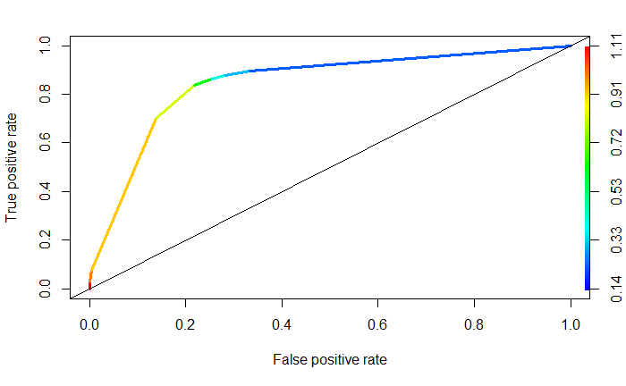

```r
pred.rocr.new <- predict(New_model, newdata=test, type="prob")[,2]
f.pred.new <- prediction(pred.rocr.new, test$income)
f.perf.new <- performance(f.pred.new, "tpr", "fpr")
plot(f.perf.new, colorize=T, lwd=3)
abline(0,1)
```

```r
auc <- performance(f.pred.new, measure = "auc")
cat(paste("The area under curve (AUC) for this model is ", round(auc@y.values[[1]], 3)))
```

```
The area under curve (AUC) for this model is  0.846
```

The Balance accuracy when there was a class imbalance is 0.726 (i.e) the model can predict at 72.6% accuracy.

The Balance accuracy with the new model(No class imbalance) is 0.809 (i.e) the model can predict at 80.9% accuracy.

The Sensitivity and the specificity of the class imbalance model is 0.948,0.504.

The Sensitivity and the specificity of the new model with no class imbalance is 0.782,0.835.

We can infer that the new model has lower sensitivity and higher specificity than the class imbalance model.

Balance accuracy for the class imbalance model is lower than the no class imbalance model.

The Aoc of the new model is slightly higer than the Class imbalance model. The new model AOC is 0.846 and AOC of the class imbalance model is 0.843.

### Question 2.2-A

Random Forest

```r
library(randomForest)
set.seed(1122)
```

```r
str(train)
```

```
'data.frame':   30161 obs. of  15 variables:
 $ age           : int  39 50 38 53 28 37 49 52 31 42 ...
 $ workclass     : Factor w/ 9 levels "?","Federal-gov",..: 8 7 5 5 5 5 5 7 5 5 ...
 $ fnlwgt        : int  77516 83311 215646 234721 338409 284582 160187 209642 45781 159449 ...
 $ education     : Factor w/ 16 levels "10th","11th",..: 10 10 12 2 10 13 7 12 13 10 ...
 $ education_num : int  13 13 9 7 13 14 5 9 14 13 ...
 $ marital_status: Factor w/ 7 levels "Divorced","Married-AF-spouse",..: 5 3 1 3 3 3 4 3 5 3 ...
 $ occupation    : Factor w/ 15 levels "?","Adm-clerical",..: 2 5 7 7 11 5 9 5 11 5 ...
 $ relationship  : Factor w/ 6 levels "Husband","Not-in-family",..: 2 1 2 1 6 6 2 1 2 1 ...
 $ race          : Factor w/ 5 levels "Amer-Indian-Eskimo",..: 5 5 5 3 3 5 3 5 5 5 ...
 $ sex           : Factor w/ 2 levels "Female","Male": 2 2 2 2 1 1 1 2 1 2 ...
 $ capital_gain  : int  2174 0 0 0 0 0 0 0 14084 5178 ...
 $ capital_loss  : int  0 0 0 0 0 0 0 0 0 0 ...
 $ hours_per_week: int  40 13 40 40 40 40 16 45 50 40 ...
 $ native_country: Factor w/ 41 levels "?","Cambodia",..: 39 39 39 39 6 39 23 39 39 39 ...
 $ income        : Factor w/ 2 levels "<=50K",">50K": 1 1 1 1 1 1 1 2 2 2 ...
```

```r
table(train$income)
```

```
<=50K  >50K
22653  7508
```

```r
table(test$income)
```

```
<=50K  >50K
11360  3700
```

```r
random_model <- randomForest(income ~ ., data=train,importance=T)
Predicted_Value_RF <- predict(random_model, test, type="class")
RF_cm <- confusionMatrix(Predicted_Value_RF,test$income)
```

```r
random_model
```

```
Call:
 randomForest(formula = income ~ ., data = train, importance = T)
               Type of random forest: classification
                     Number of trees: 500
No. of variables tried at each split: 3

        OOB estimate of  error rate: 18.2%
Confusion matrix:
      <=50K >50K class.error
<=50K 22592   61     0.00269
>50K   5424 2084     0.72243
```

```r
RF_cm
```

```
Confusion Matrix and Statistics

          Reference
Prediction <=50K  >50K
     <=50K 11328  2711
     >50K     32   989

               Accuracy : 0.818
                 95% CI : (0.812, 0.824)
    No Information Rate : 0.754
    P-Value [Acc > NIR] : <2e-16

                  Kappa : 0.35
 Mcnemar's Test P-Value : <2e-16

            Sensitivity : 0.997
            Specificity : 0.267
         Pos Pred Value : 0.807
         Neg Pred Value : 0.969
             Prevalence : 0.754
         Detection Rate : 0.752
   Detection Prevalence : 0.932
      Balanced Accuracy : 0.632

       'Positive' Class : <=50K
```

### Question 2.2-A-(i)-(ii)-(iii)

```r
RF_Balance_Acurracy <- as.numeric(formatC(RF_cm$byClass[11], digits = 3, format = "f"))
RF_Acurracy <- as.numeric(formatC(RF_cm$overall[1], digits = 3, format = "f"))
RF_Sensitivity <- as.numeric(formatC(RF_cm$byClass[1], digits = 3, format = "f"))
RF_Specificity <- as.numeric(formatC(RF_cm$byClass[2], digits = 3, format = "f"))
cat(paste("The Balance Accuracy of the model is ",RF_Balance_Acurracy,"\n"))
```

```
The Balance Accuracy of the model is  0.632
```

```r
cat(paste("The Accuracy of the model is ",RF_Acurracy,"\n"))
```

```
The Accuracy of the model is  0.818
```

```r
cat(paste("The Sensitivity of the model is ",RF_Sensitivity,"\n"))
```

```
The Sensitivity of the model is  0.997
```

```r
cat(paste("The Specificity of the model is ",RF_Specificity,"\n"))
```

```
The Specificity of the model is  0.267
```

### Question 2.2-A-(iv)

```r
table(test$income)
```

```
<=50K  >50K
11360  3700
```

In the test data set we have 11360 observations of class <=50K and 3700 observations of class >50K.

sensitivity and the specificity makes sense because class <=50K has 11360 observations which is approximately 3 times the number of observations of the class >50K.

So the Sensitivity is very high than specificity.Note Here the positive class is the majority class “<=50K”.

### Question 2.2-A-(v)

since the number of observation of the class “<=50K” is 3 times higher than the observations of the class “>50K” and the positive class is “<=50K” so the sensitivity is high (Positive class) and specificity is low (negative class).

### Question 2.2-A-(vi)

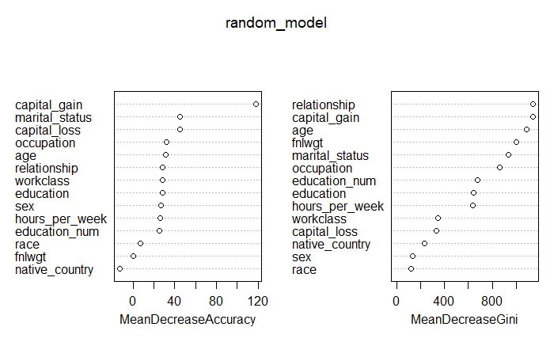

```r
varImpPlot(random_model)
```

For MeanDecreaseAccuracy – The most important variable is capital_gain and the least important variable is native_country. For MeanDecreaseGini – The most important variable is relationship and the least important variable is Race.

### Question 2.2-A-(vii)

```r
print(random_model)
```

```
Call:
 randomForest(formula = income ~ ., data = train, importance = T)
               Type of random forest: classification
                     Number of trees: 500
No. of variables tried at each split: 3

        OOB estimate of  error rate: 18.2%
Confusion matrix:
      <=50K >50K class.error
<=50K 22592   61     0.00269
>50K   5424 2084     0.72243
```

The number of variables tied at each split is 3.

## Question 2.2-B-(i)

```r
str(train)
```

```
'data.frame':   30161 obs. of  15 variables:
 $ age           : int  39 50 38 53 28 37 49 52 31 42 ...
 $ workclass     : Factor w/ 9 levels "?","Federal-gov",..: 8 7 5 5 5 5 5 7 5 5 ...
 $ fnlwgt        : int  77516 83311 215646 234721 338409 284582 160187 209642 45781 159449 ...
 $ education     : Factor w/ 16 levels "10th","11th",..: 10 10 12 2 10 13 7 12 13 10 ...
 $ education_num : int  13 13 9 7 13 14 5 9 14 13 ...
 $ marital_status: Factor w/ 7 levels "Divorced","Married-AF-spouse",..: 5 3 1 3 3 3 4 3 5 3 ...
 $ occupation    : Factor w/ 15 levels "?","Adm-clerical",..: 2 5 7 7 11 5 9 5 11 5 ...
 $ relationship  : Factor w/ 6 levels "Husband","Not-in-family",..: 2 1 2 1 6 6 2 1 2 1 ...
 $ race          : Factor w/ 5 levels "Amer-Indian-Eskimo",..: 5 5 5 3 3 5 3 5 5 5 ...
 $ sex           : Factor w/ 2 levels "Female","Male": 2 2 2 2 1 1 1 2 1 2 ...
 $ capital_gain  : int  2174 0 0 0 0 0 0 0 14084 5178 ...
 $ capital_loss  : int  0 0 0 0 0 0 0 0 0 0 ...
 $ hours_per_week: int  40 13 40 40 40 40 16 45 50 40 ...
 $ native_country: Factor w/ 41 levels "?","Cambodia",..: 39 39 39 39 6 39 23 39 39 39 ...
 $ income        : Factor w/ 2 levels "<=50K",">50K": 1 1 1 1 1 1 1 2 2 2 ...
```

```
mtry = 3  OOB error = 18.21%
Searching left ...
mtry = 2    OOB error = 17.8%
0.0222 0.01
Searching right ...
mtry = 4    OOB error = 18.17%
-0.0207 0.01
```

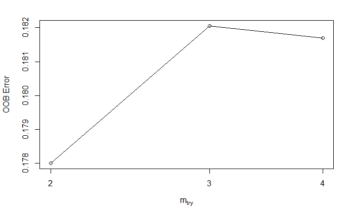

```r
mtry <- tuneRF(train[,-15], train[,15], ntreeTry=500,stepFactor=1.5,improve=0.01, trace=TRUE, plot=TRUE)
```

```r
print(mtry)
```

```
      mtry OOBError
2.OOB    2    0.178
3.OOB    3    0.182
4.OOB    4    0.182
```

first the search begins with default value mtry=3 with 18.2% oob error and on searching towards the left with mtry=2 it finds oob error to be 17.8% and then towards the right with mtry=4 and oob error as 18.2%

### Question 2.2-B-(ii)

Mtry value selected is 2.

### Question 2.2-B-(iii)

```r
random_model_update <- randomForest(income ~ ., data=train,importance=T,mtry=2)
random_model_update
```

```
Call:
 randomForest(formula = income ~ ., data = train, importance = T,      mtry = 2)
               Type of random forest: classification
                     Number of trees: 500
No. of variables tried at each split: 2

        OOB estimate of  error rate: 17.7%
Confusion matrix:
      <=50K >50K class.error
<=50K 22544  109     0.00481
>50K   5229 2279     0.69646
```

```r
Predicted_Value_RF_new <- predict(random_model_update, test, type="class")
head(Predicted_Value_RF_new)
```

```
    1     2     3     4     6     8
<=50K <=50K <=50K  >50K <=50K <=50K
Levels: <=50K >50K
```

```r
RF_cm_new <- confusionMatrix(Predicted_Value_RF_new,test$income)
RF_cm_new
```

```
Confusion Matrix and Statistics

          Reference
Prediction <=50K  >50K
     <=50K 11312  2604
     >50K     48  1096

               Accuracy : 0.824
                 95% CI : (0.818, 0.83)
    No Information Rate : 0.754
    P-Value [Acc > NIR] : <2e-16

                  Kappa : 0.381
 Mcnemar's Test P-Value : <2e-16

            Sensitivity : 0.996
            Specificity : 0.296
         Pos Pred Value : 0.813
         Neg Pred Value : 0.958
             Prevalence : 0.754
         Detection Rate : 0.751
   Detection Prevalence : 0.924
      Balanced Accuracy : 0.646

       'Positive' Class : <=50K
```

```r
RF_Balance_Acurracy_new <- as.numeric(formatC(RF_cm_new$byClass[11], digits = 3, format = "f"))
RF_Acurracy_new <- as.numeric(formatC(RF_cm_new$overall[1], digits = 3, format = "f"))
RF_Sensitivity_new <- as.numeric(formatC(RF_cm_new$byClass[1], digits = 3, format = "f"))
RF_Specificity_new <- as.numeric(formatC(RF_cm_new$byClass[2], digits = 3, format = "f"))
cat(paste("The Balance Accuracy of the model is ",RF_Balance_Acurracy_new,"\n"))
```

```
The Balance Accuracy of the model is  0.646
```

```r
cat(paste("The Accuracy of the model is ",RF_Acurracy_new,"\n"))
```

```
The Accuracy of the model is  0.824
```

```r
cat(paste("The Sensitivity of the model is ",RF_Sensitivity_new,"\n"))
```

```
The Sensitivity of the model is  0.996
```

```r
cat(paste("The Specificity of the model is ",RF_Specificity_new,"\n"))
```

```
The Specificity of the model is  0.296
```

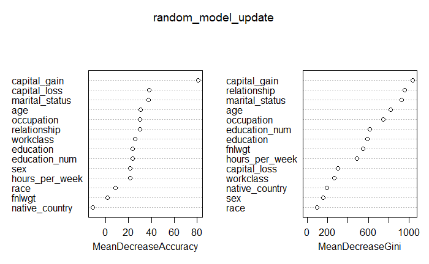

```r
varImpPlot(random_model_update)
```

For meaDecreaseAccuracy the most important variable is Capital_gain and the least important variable is native_country.

For meaDecreaseGini the most important variable is Capital_gain and the least important variable is Race.

### Question 2.2-B-(iv)

From the two models we can infer that the Accuracy,Balance_Accuracy and Specificity has higher values for the new model with mtry=2 compared to the old model with splits 3.

For both the models Sensitivity remains the same.For both the models variable importance remains same but in old model for meandecreasedgini most important variable relationship and capital_gain has almost equal value.

### Question 2.3

Association Rules

```r
library(arules)
```

```r
transaction_groceries <- read.transactions("groceries.csv", sep=",")
transaction_groceries
```

```
transactions in sparse format with
 9835 transactions (rows) and
 169 items (columns)
```

```r
summary(transaction_groceries)
```

```
transactions as itemMatrix in sparse format with
 9835 rows (elements/itemsets/transactions) and
 169 columns (items) and a density of 0.0261

most frequent items:
      whole milk other vegetables       rolls/buns             soda           yogurt
            2513             1903             1809             1715             1372
         (Other)
           34055

element (itemset/transaction) length distribution:
sizes
   1    2    3    4    5    6    7    8    9   10   11   12   13   14   15   16   17   18   19
2159 1643 1299 1005  855  645  545  438  350  246  182  117   78   77   55   46   29   14   14
  20   21   22   23   24   26   27   28   29   32
   9   11    4    6    1    1    1    1    3    1

   Min. 1st Qu.  Median    Mean 3rd Qu.    Max.
    1.0     2.0     3.0     4.4     6.0    32.0

includes extended item information - examples:
            labels
1 abrasive cleaner
2 artif. sweetener
3   baby cosmetics
```

### Question 2.3-(i)

```r
rules_groceries <- apriori(transaction_groceries)
```

```
Apriori

Parameter specification:
 confidence minval smax arem  aval originalSupport maxtime support minlen maxlen target   ext
        0.8    0.1    1 none FALSE            TRUE       5     0.1      1     10  rules FALSE

Algorithmic control:
 filter tree heap memopt load sort verbose
    0.1 TRUE TRUE  FALSE TRUE    2    TRUE

Absolute minimum support count: 983

set item appearances ...[0 item(s)] done [0.01s].
set transactions ...[169 item(s), 9835 transaction(s)] done [0.02s].
sorting and recoding items ... [8 item(s)] done [0.01s].
creating transaction tree ... done [0.00s].
checking subsets of size 1 2 done [0.02s].
writing ... [0 rule(s)] done [0.01s].
creating S4 object  ... done [0.01s].
```

```r
summary(rules_groceries)
```

```
set of 0 rules
```

```r
inspect(head(rules_groceries, by="confidence"))
```

No of rules at a support value of 0.1 is Zero

### Question 2.3-(ii)

```r
rules_updated <- apriori(transaction_groceries, parameter=list(supp = 0.001))
```

```
Apriori

Parameter specification:
 confidence minval smax arem  aval originalSupport maxtime support minlen maxlen target   ext
        0.8    0.1    1 none FALSE            TRUE       5   0.001      1     10  rules FALSE

Algorithmic control:
 filter tree heap memopt load sort verbose
    0.1 TRUE TRUE  FALSE TRUE    2    TRUE

Absolute minimum support count: 9

set item appearances ...[0 item(s)] done [0.01s].
set transactions ...[169 item(s), 9835 transaction(s)] done [0.09s].
sorting and recoding items ... [157 item(s)] done [0.02s].
creating transaction tree ... done [0.00s].
checking subsets of size 1 2 3 4 5 6 done [0.05s].
writing ... [410 rule(s)] done [0.01s].
creating S4 object  ... done [0.01s].
```

At a support value of 0.001 we get >400 rules.

```r
inspect(sort(rules_updated,by = "support")[1:10])
```

```
     lhs                        rhs                support confidence lift count
[1]  {citrus fruit,
      root vegetables,
      tropical fruit,
      whole milk}            => {other vegetables} 0.00315      0.886 4.58    31
[2]  {curd,
      domestic eggs,
      other vegetables}      => {whole milk}       0.00285      0.824 3.22    28
[3]  {curd,
      hamburger meat}        => {whole milk}       0.00254      0.806 3.16    25
[4]  {herbs,
      rolls/buns}            => {whole milk}       0.00244      0.800 3.13    24
[5]  {herbs,
      tropical fruit}        => {whole milk}       0.00234      0.821 3.21    23
[6]  {citrus fruit,
      other vegetables,
      root vegetables,
      yogurt}                => {whole milk}       0.00234      0.821 3.21    23
[7]  {butter,
      other vegetables,
      pork}                  => {whole milk}       0.00224      0.846 3.31    22
[8]  {rolls/buns,
      root vegetables,
      tropical fruit,
      yogurt}                => {whole milk}       0.00224      0.815 3.19    22
[9]  {grapes,
      tropical fruit,
      whole milk}            => {other vegetables} 0.00203      0.800 4.13    20
[10] {fruit/vegetable juice,
      other vegetables,
      root vegetables,
      yogurt}                => {whole milk}       0.00203      0.833 3.26    20
```

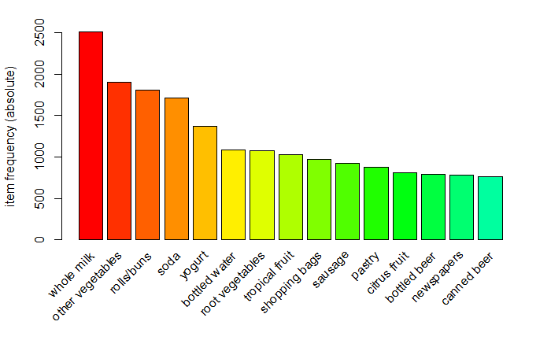

```r
itemFrequencyPlot(transaction_groceries,topN =15,col=rainbow(32),type="absolute")
```

## Question 2.3-(iii)

Most frequently bought item is Whole Milk and its frequency is 2513.

```r
table(unlist(LIST(transaction_groceries)))
```

```
         abrasive cleaner          artif. sweetener            baby cosmetics
                       35                        32                         6
                baby food                      bags             baking powder
                        1                         4                       174
         bathroom cleaner                      beef                   berries
                       27                       516                       327
                beverages              bottled beer             bottled water
                      256                       792                      1087
                   brandy               brown bread                    butter
                       41                       638                       545
              butter milk                  cake bar                   candles
                      275                       130                        88
                    candy               canned beer               canned fish
                      294                       764                       148
             canned fruit         canned vegetables                  cat food
                       32                       106                       229
                  cereals               chewing gum                   chicken
                       56                       207                       422
                chocolate     chocolate marshmallow              citrus fruit
                      488                        89                       814
                  cleaner           cling film/bags              cocoa drinks
                       50                       112                        22
                   coffee            condensed milk         cooking chocolate
                      571                       101                        25
                 cookware                     cream              cream cheese
                       27                        13                       390
                     curd               curd cheese               decalcifier
                      524                        50                        15
              dental care                   dessert                 detergent
                       57                       365                       189
             dish cleaner                    dishes                  dog food
                      103                       173                        84
            domestic eggs  female sanitary products         finished products
                      624                        60                        64
                     fish                     flour            flower (seeds)
                       29                       171                       102
   flower soil/fertilizer               frankfurter            frozen chicken
                       19                       580                         6
           frozen dessert               frozen fish             frozen fruits
                      106                       115                        12
```

[output cut: 59 more lines]

```
                       36                        17                        51
            spread cheese                     sugar             sweet spreads
                      110                       333                        89
                    syrup                       tea                   tidbits
                       32                        38                        23
           toilet cleaner            tropical fruit                    turkey
                        7                      1032                        80
                 UHT-milk                   vinegar                   waffles
                      329                        64                       378
       whipped/sour cream                    whisky               white bread
                      705                         8                       414
               white wine                whole milk                    yogurt
                      187                      2513                      1372
                 zwieback
                       68
```

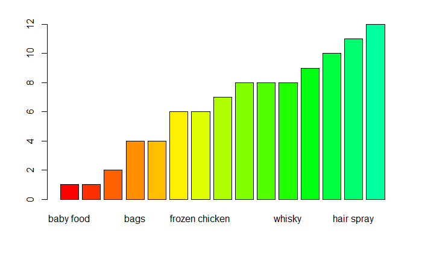

```r
barplot(sort(table(unlist(LIST(transaction_groceries))))[1:15],col=rainbow(32))
```

The least frequent item bought is baby food and sound storage medium with frequency 1.

```r
inspect(sort(rules_updated,by = "support")[1:5])
```

```
    lhs                   rhs                support confidence lift count
[1] {citrus fruit,
     root vegetables,
     tropical fruit,
     whole milk}       => {other vegetables} 0.00315      0.886 4.58    31
[2] {curd,
     domestic eggs,
     other vegetables} => {whole milk}       0.00285      0.824 3.22    28
[3] {curd,
     hamburger meat}   => {whole milk}       0.00254      0.806 3.16    25
[4] {herbs,
     rolls/buns}       => {whole milk}       0.00244      0.800 3.13    24
[5] {herbs,
     tropical fruit}   => {whole milk}       0.00234      0.821 3.21    23
```

```r
inspect(sort(rules_updated,by = "confidence")[1:5])
```

```
    lhs                                           rhs          support confidence lift count
[1] {rice,sugar}                               => {whole milk} 0.00122 1          3.91 12
[2] {canned fish,hygiene articles}             => {whole milk} 0.00112 1          3.91 11
[3] {butter,rice,root vegetables}              => {whole milk} 0.00102 1          3.91 10
[4] {flour,root vegetables,whipped/sour cream} => {whole milk} 0.00173 1          3.91 17
[5] {butter,domestic eggs,soft cheese}         => {whole milk} 0.00102 1          3.91 10
```

```r
inspect(sort(rules_updated,by = "support",decreasing = F)[1:5])
```

```
    lhs                                       rhs          support confidence lift count
[1] {cereals,curd}                         => {whole milk} 0.00102 0.909      3.56 10
[2] {butter,jam}                           => {whole milk} 0.00102 0.833      3.26 10
[3] {pastry,sweet spreads}                 => {whole milk} 0.00102 0.909      3.56 10
[4] {butter,rice,root vegetables}          => {whole milk} 0.00102 1.000      3.91 10
[5] {other vegetables,rice,tropical fruit} => {whole milk} 0.00102 0.833      3.26 10
```

```r
inspect(sort(rules_updated,by = "confidence",decreasing = F)[1:5])
```

```
    lhs                                        rhs                support confidence lift count
[1] {curd,turkey}                           => {other vegetables} 0.00122 0.8        4.13 12
[2] {fruit/vegetable juice,herbs}           => {other vegetables} 0.00122 0.8        4.13 12
[3] {herbs,rolls/buns}                      => {whole milk}       0.00244 0.8        3.13 24
[4] {onions,waffles}                        => {other vegetables} 0.00122 0.8        4.13 12
[5] {root vegetables,tropical fruit,turkey} => {other vegetables} 0.00122 0.8        4.13 12
```